# International Viewership in The NBA

```python
# Modules
import pandas as pd
import numpy as np
import plotly.plotly as py
import plotly.graph_objs as go
import string
import matplotlib.pyplot as plt
import seaborn as sns
import lxml.html as lx
import requests
import time
import re
from itertools import chain
import matplotlib.pyplot as plt
import seaborn as sns
import plotly.plotly as py
import plotly.graph_objs as go
from plotly.offline import iplot, init_notebook_mode
# Using plotly + cufflinks in offline mode
import cufflinks
cufflinks.go_offline(connected=True)
init_notebook_mode(connected=True)
from bs4 import BeautifulSoup
import requests_cache
from selenium import webdriver
requests_cache.install_cache("my_cache1")
from datetime import datetime as dt
import calendar
from sklearn.model_selection import train_test_split
from sklearn.linear_model import LinearRegression
import csv
%matplotlib inline
sns.set_palette("GnBu_d")
sns.set_style('whitegrid')

# hide code
from IPython.display import HTML

HTML('''<script>
code_show=true;
function code_toggle() {
 if (code_show){
 $('div.input').hide();
 } else {
 $('div.input').show();
 }
 code_show = !code_show
}
$( document ).ready(code_toggle);
</script>
The raw code for this IPython notebook is by default hidden for easier reading.
To toggle on/off the raw code, click <a href="javascript:code_toggle()">here</a>.''')
```

The raw code for this IPython notebook is by default hidden for easier reading. To toggle on/off the raw code, click here.

## Introduction

The NBA, is the best Basketball association in the whole world, and though it started in America the league over the year continued to expand globally. Today the international fan base plays a big role for the NBA and each year they try to expand even more, for example by having some games played in different countries around the world. The goal of our project is to come up with an interpretable model to predict the amount of international viewers a game may have. We retrieved our data directly from the NBA and some of the features were scraped online, which will be discussed more in depth later on. Below is a list of features for each factor:

- Temporal
  - Game Date
  - Month
  - Day of Week
- Player and game data
  - Total All Stars in Game
  - Team Success
  - Late Game Score Difference
  - Total International Players in Game
  - Total Final Score
  - Total time-outs taken
- Social media impact
  - Twitter Followers
- Team value
  - Forbe's Annual Team Valuation

In our project we explored different features of the four factors listed above. Our goal was to construct a model to predict the number of international viewers per game. We analyzed the features above before implementing them into the model to get insight on the results of the predictive model and better understand the trends in the features.

### Data sets

We were given four datasets from the NBA listed below:

- Game Data
- Player Data
- Training Data
- Test data

All of these data sets range contain data pertaining to the 2016-2017 and 2017-2018 NBA season. Additionally, all these data sets are all linked through the common column of game_id Besides the data sets that were given to us we had to web scrape data for team value, social media, and additional game data which will be discussed in late section.

#### Game Data

The game data included various features relating to the game. below is a couple rows from this data set which shows what type of features were present

```python
game_dat = pd.read_csv("game_data.csv")
game_dat[0:3]
```

|  | Season | Game_ID | Game_Date | Team | Location | Wins_Entering_Gm | Losses_Entering_Gm | Team_Minutes | Final_Score | Lead_Changes | Ties | Largest_Lead | Full_Timeouts | Short_Timeouts | Qtr_4_Score | L2M_Score |
| --- | --- | --- | --- | --- | --- | --- | --- | --- | --- | --- | --- | --- | --- | --- | --- | --- |
| 0 | 2016-17 | 21600001 | 10/25/2016 | CLE | H | 0 | 0 | 240.0 | 117.0 | 1.0 | 3.0 | 32.0 | 4.0 | 1.0 | 82.0 | 113.0 |
| 1 | 2016-17 | 21600001 | 10/25/2016 | NYK | A | 0 | 0 | 240.0 | 88.0 | 0.0 | 1.0 | 4.0 | 4.0 | 2.0 | 64.0 | 84.0 |
| 2 | 2016-17 | 21600002 | 10/25/2016 | POR | H | 0 | 0 | 240.0 | 113.0 | 6.0 | 6.0 | 13.0 | 5.0 | 0.0 | 77.0 | 104.0 |

#### Player Data

The player data contains basketball statistics on each player from each NBA team for each individual game. Below is a couple rows from this data set which displays the features present.

```python
player_dat = pd.read_csv("player_data.csv")
player_dat[0:3]
```

|  | Season | Game_ID | Game_Date | Team | Person_ID | Name | ASG_Team | Active_Status | Minutes | Points | ... | Steals | Blocks | Turnovers | Field_Goals | Field_Goals_Attempted | Three_Pointers | Three_Pointers_Attempted | Free_Throws | Free_Throws_Attempted | Personal_Fouls |
| --- | --- | --- | --- | --- | --- | --- | --- | --- | --- | --- | --- | --- | --- | --- | --- | --- | --- | --- | --- | --- | --- |
| 0 | 2016-17 | 21600001 | 10/25/2016 | CLE | 101112 | Channing Frye | None | Active | 14.0 | 6.0 | ... | 1.0 | 1.0 | 1.0 | 2.0 | 6.0 | 2.0 | 5.0 | 0.0 | 0.0 | 4.0 |
| 1 | 2016-17 | 21600001 | 10/25/2016 | CLE | 201567 | Kevin Love | East ASG | Active | 25.0 | 23.0 | ... | 3.0 | 0.0 | 2.0 | 6.0 | 15.0 | 2.0 | 6.0 | 9.0 | 12.0 | 3.0 |
| 2 | 2016-17 | 21600001 | 10/25/2016 | CLE | 202681 | Kyrie Irving | East ASG | Active | 30.0 | 29.0 | ... | 2.0 | 0.0 | 0.0 | 12.0 | 22.0 | 4.0 | 7.0 | 1.0 | 1.0 | 1.0 |

3 rows × 23 columns

#### Training and Test data

The training and test data include the same information. Both contain information on how many international viewers a game had from each individual country. These countries are not identified but are rather given an ID so there is no way to really analyze viewership by a specific country. When analyzing a features effect on international viewership we used the training data set as it has information on more game than the testing data set. We used the testing data set to measure how good our predictive model is. Below is a couple rows from the training data set.

```python
training_dat = pd.read_csv("training_set.csv")
test_dat = pd.read_csv("test_set.csv")
training_dat[0:3]
```

|  | Season | Game_ID | Game_Date | Away_Team | Home_Team | Country | Rounded Viewers |
| --- | --- | --- | --- | --- | --- | --- | --- |
| 0 | 2016-17 | 21600001 | 10/25/2016 | NYK | CLE | C113 | 18 |
| 1 | 2016-17 | 21600001 | 10/25/2016 | NYK | CLE | C193 | 1 |
| 2 | 2016-17 | 21600001 | 10/25/2016 | NYK | CLE | C126 | 4 |

### Assumptions made

Since our main data came directly from the NBA, we did not need to clean any data and all of the features were the appropriate type. The only thing we were unable to figure out was the units of the rounded viewers which is present in the training and testing data set. T However, this does not have any affect on our analysis as the units of the "rounded viewers" column will not change any pattern or trend this feature may have with other features.

## 1 Temporal Impact on International Viewership

### 1.1 Methodology

We would like to see if viewership numbers do change over certain periods, which would be an indication that would lead us to believe there is an association between time (seasonal/temporal) and viewership. Here we will explore how average international viewership persists over game dates, months, and day of week over the two seasons from 2016-2018.

### 1.2 Analysis

#### 1.2.1 Viewership by Unique Date

```python
copy = training_dat.copy()
train_bydate = copy
train_bydate["Game_Date"] = pd.to_datetime(train_bydate["Game_Date"])
train_bydate["Game_ID"] = train_bydate["Game_ID"].apply(str)
tot_views_unique_game = train_bydate.groupby(["Game_ID","Game_Date"])["Rounded Viewers"].sum() # total viewers for each unique game
tot_views_unique_game_df = pd.DataFrame(tot_views_unique_game.reset_index())
avg_views_by_date = tot_views_unique_game_df.groupby("Game_Date")["Rounded Viewers"].mean() # average viewers per game for each date
avg_views_by_date_df = pd.DataFrame(avg_views_by_date)
tot_views_unique_game_df.head() # total viewers for each game

# subset by date <https://stackoverflow.com/questions/22898824/filtering-pandas-dataframes-on-dates>
```

|  | Game_ID | Game_Date | Rounded Viewers |
| --- | --- | --- | --- |
| 0 | 21600001 | 2016-10-25 | 57691 |
| 1 | 21600002 | 2016-10-25 | 40740 |
| 2 | 21600003 | 2016-10-25 | 60428 |
| 3 | 21600004 | 2016-10-26 | 22756 |
| 4 | 21600005 | 2016-10-26 | 33922 |

```python
#### Total International Viewership for each Date of 2016-2017 Season

# first season
start_date = '2016-10-24'
end_date = '2017-4-13'
first_train1 = tot_views_unique_game_df[(tot_views_unique_game_df["Game_Date"] > start_date) & (tot_views_unique_game_df["Game_Date"] < end_date)]
first_train1 = pd.DataFrame(first_train1.groupby("Game_Date")["Rounded Viewers"].mean())

plot1 = first_train1['Rounded Viewers'].iplot(
    mode = 'lines+markers',
    opacity = 0.8,
    size = 8,
    symbol = 1,
    xTitle = 'Date',
    yTitle = 'Average Rounded Viewer Count',
    title = 'Average International Viewership Per Game Over 2016-2017 Season')

# 2nd season
start_date = '2017-10-16'
end_date = '2018-4-13'
first_train2 = tot_views_unique_game_df[(tot_views_unique_game_df["Game_Date"] > start_date) & (tot_views_unique_game_df["Game_Date"] < end_date)]
first_train2 = pd.DataFrame(first_train2.groupby("Game_Date")["Rounded Viewers"].mean())

plot2 = first_train2['Rounded Viewers'].iplot(
    mode = 'lines+markers',
    opacity = 0.8,
    size = 8,
    symbol = 1,
    xTitle = 'Date',
    yTitle = 'Average Rounded Viewer Count',
    title = 'Average International Viewership By Date Over 2017-2018 Season')
plot1
plot2

### Total International Viewership for each Date of 2017-2018 Season
```

[interactive chart not shown]

#### 1.2.2 Viewership by Month and Day of Week

```python
# By Month
avg_views_by_date_df2 = avg_views_by_date_df.reset_index()
train_bymonth = avg_views_by_date_df2.groupby(avg_views_by_date_df2['Game_Date'].dt.strftime('%B'))['Rounded Viewers'].mean()
train_bymonth_df = pd.DataFrame(train_bymonth)
train_bymonth_df = pd.DataFrame(train_bymonth.reindex(["October", "November", "December", "January", "February", "March", "April"]))

plot3 = train_bymonth_df['Rounded Viewers'].iplot(
    mode = 'lines+markers',
    opacity = 0.8,
    size = 8,
    symbol = 1,
    xTitle = 'Date',
    yTitle = 'Average Rounded Viewer Count',
    title = 'Average International Viewership Per Game by Month')

# By day of week
train_byday = avg_views_by_date_df2.groupby(avg_views_by_date_df2['Game_Date'].dt.strftime('%A'))['Rounded Viewers'].mean() # group by day of week and find average viewers per game
train_byday = train_byday.reindex(["Sunday", "Monday", "Tuesday", "Wednesday", "Thursday", "Friday", "Saturday"])
train_byday_df = pd.DataFrame(train_byday)

plot4 = train_byday_df['Rounded Viewers'].iplot(
    mode = 'lines+markers',
    opacity = 0.8,
    size = 8,
    symbol = 1,
    xTitle = 'Day',
    yTitle = 'Average Rounded Viewer Count',
    title = 'Average International Viewership Per Game by Day of Week')


plot3
plot4

# Group by month <https://stackoverflow.com/questions/44908383/how-can-i-group-by-month-from-a-date-field-using-python-pandas>
# Re-order rows <https://stackoverflow.com/questions/30009948/how-to-reorder-indexed-rows-based-on-a-list-in-pandas-data-frame>
```

[interactive chart not shown]

### 1.3 Findings

In reference to the graph of the average viewership by game dates, most of the games tend to average 10,000 to 30,000 international viewers per game. Looking closer at the 2016-2017 season, we can see from the graphs that early in the season the international viewership is at its highest, but that over time the international viewership drops steadily.

There are multiple unique game dates were the average international viewership is unusually high. Other than the first few games of the season, there are some other dates that spike unusually high. One date where international viewership numbers increase significantly in both the 2016-2017 and 2017-2018 season is December 25, which is Christmas. Upon further research, we discovered that these games are hand-picked by the NBA, in recent years games that were played on December 25 include a rematch of the NBA Finals.

From the graph of viewership numbers by game date, we can see an overall negative trend, but this trend is made clearer when looking at how viewership changes over the months. Also, games on thursdays average the most viewers.

**Source**

- Why Christmas Day is special in NBA https://en.wikipedia.org/wiki/National_Basketball_Association_Christmas_games

## 2 Social media impact

### 2.1 Twitter followership

#### 2.1.1 Methodology

To explore this factor, we first scraped the official NBA team twitter accounts to get their respective follower counts and then used team performance data, specifally using the game ID, rounded viewers, and away/home teams features to get the average viewership for each team. We then combined this with the corresponding team's number of twitter followers to see if there is any correlation.

#### 2.1.2 Analysis

```python
# Twitter handles of all 30 official NBA team accounts
teams = ['raptors', 'warriors', 'nuggets', 'okcthunder', 'pelicansnba',
         'dallasmavs', 'hornets', 'lakers', 'nyknicks', 'timberwolves',
         'laclippers','orlandomagic','pacers', 'cavs', 'houstonrockets',
         'brooklynnets', 'suns', 'spurs', 'utahjazz', 'celtics', 'atlhawks',
         'detroitpistons', 'chicagobulls', 'sixers', 'bucks', 'washwizards',
         'miamiheat', 'memgrizz', 'trailblazers', 'sacramentokings']
```

```python
# Scrape the number of followers from each NBA account and store in data.csv
with open('data.csv','w') as file:
    filewriter = csv.writer(file, delimiter=',', quotechar='|', quoting=csv.QUOTE_MINIMAL)
    filewriter.writerow(['Team', 'Number of Followers'])

    for handle in teams:
        temp = requests.get('https://twitter.com/'+handle)
        bs = BeautifulSoup(temp.text,'lxml')

        try:
            follow_box = bs.find('li',{'class':'ProfileNav-item ProfileNav-item--followers'})
            followers = follow_box.find('a').find('span',{'class':'ProfileNav-value'})
            numFollows = followers.get('data-count')

        except:
            print('Account name not found...')

        filewriter.writerow([handle, numFollows])

file.close()
```

```python
# Combine Away Teams and Home Teams columns into new column for new dataframe using just 3 features:
# game ID, rounded viewers and teams playing in the game
training_set = pd.read_csv("training_set.csv")
teams = list(training_set["Away_Team"].unique())

combined = training_set["Away_Team"] + "," + training_set["Home_Team"]
training_set["teams_in_game"] = combined
rounded_viewers = training_set[['Game_ID','Rounded Viewers', 'teams_in_game']]
rounded_viewers.head(5)
```

|  | Game_ID | Rounded Viewers | teams_in_game |
| --- | --- | --- | --- |
| 0 | 21600001 | 18 | NYK,CLE |
| 1 | 21600001 | 1 | NYK,CLE |
| 2 | 21600001 | 4 | NYK,CLE |
| 3 | 21600001 | 11 | NYK,CLE |
| 4 | 21600001 | 3 | NYK,CLE |

```python
# Sum up rounded viewers for each game in new dataframe
sum_views = pd.DataFrame(rounded_viewers.groupby('Game_ID')['Rounded Viewers'].sum())
sum_views.head()
```

| Game_ID | Rounded Viewers |
| --- | --- |
| 21600001 | 57691 |
| 21600002 | 40740 |
| 21600003 | 60428 |
| 21600004 | 22756 |
| 21600005 | 33922 |

```python
# Add in corresponding teams playing in each game
sum_views = pd.DataFrame(rounded_viewers.groupby('Game_ID')['Rounded Viewers'].sum())
sum_views.head()

teams_in_game_listed = pd.DataFrame(rounded_viewers.groupby('Game_ID')['teams_in_game'].unique())
sum_views["teams_in_game"] = teams_in_game_listed
sum_views.head()
```

| Game_ID | Rounded Viewers | teams_in_game |
| --- | --- | --- |
| 21600001 | 57691 | [NYK,CLE] |
| 21600002 | 40740 | [UTA,POR] |
| 21600003 | 60428 | [SAS,GSW] |
| 21600004 | 22756 | [MIA,ORL] |
| 21600005 | 33922 | [DAL,IND] |

```python
# This function finds the average number of views for a team
def find_avg_views(team):
    '''Takes a team and computes the average number of views'''

    total_view = 0
    length = 0
    for idx,value in enumerate(list(sum_views["teams_in_game"])):
        if team in value[0]:
            total_view += list(sum_views["Rounded Viewers"])[idx]
            length += 1

    average_views = total_view / length
    return [team, average_views]

team_avg_views = [find_avg_views(team) for team in teams]
```

```python
# The average number of views for each team
team_avg_views = [find_avg_views(team) for team in teams]
team_avg_views[0:5]
```

```
[['NYK', 17971.84892086331],
 ['SAS', 19676.16176470588],
 ['UTA', 12989.608695652174],
 ['BKN', 12836.248062015504],
 ['CHA', 13155.212598425196]]
```

```python
# Combine team average views and corresponding number of twitter followers for each team into new dataframe
teamz = [item[0] for item in team_avg_views]
avg_views = [item[1] for item in team_avg_views]

twitter = pd.read_csv("data.csv")

team_and_views = pd.DataFrame({
    "team": teamz,
    "avg_views": avg_views,
})

team_and_views = team_and_views.sort_values(by="team")
team_and_views = team_and_views.reset_index(drop = True)
team_and_views["twitter_followers"] = twitter["Number of Followers"]
team_and_views_byfollowers = team_and_views.sort_values(by=['twitter_followers'])
team_and_views_byviews = team_and_views.sort_values(by=['avg_views'])

# team_and_views_byfollowers
# team_and_views
# team_and_views_byviews

#### prepare interactive plot
teams = list(training_set["Away_Team"].unique()) # list of all teams

combined = training_set["Away_Team"] + "," + training_set["Home_Team"]
training_set["teams_in_game"] = combined
rounded_viewers = training_set[['Game_ID','Rounded Viewers', 'teams_in_game']]
sum_views = pd.DataFrame(rounded_viewers.groupby('Game_ID')['Rounded Viewers'].sum())
teams_in_game_listed = pd.DataFrame(rounded_viewers.groupby('Game_ID')['teams_in_game'].unique())
sum_views["teams_in_game"] = teams_in_game_listed

def find_avg_views(team):
    '''Takes a team and computes the average number of views'''

    total_view = 0
    length = 0
    for idx,value in enumerate(list(sum_views["teams_in_game"])):
        if team in value[0]:
            total_view += list(sum_views["Rounded Viewers"])[idx]
            length += 1

    average_views = total_view / length

    #return {team: average_views}
    return [team, average_views]

team_avg_views = [find_avg_views(team) for team in teams]

teamz = [item[0] for item in team_avg_views]
avg_views = [item[1] for item in team_avg_views]


twitter = pd.read_csv("data.csv")
twitter

#convert = pd.DataFrame(team_avg_views)
team_and_views = pd.DataFrame({
    "team": teamz,
    "avg_views": avg_views,
})
team_and_views = team_and_views.sort_values(by="team")
team_and_views = team_and_views.reset_index(drop = True)
#team_and_views["twitter_followers"] = twitter["Number of Followers"]
team_and_views
```

|  | team | avg_views |
| --- | --- | --- |
| 0 | ATL | 12830.521429 |
| 1 | BKN | 12836.248062 |
| 2 | BOS | 22926.250000 |
| 3 | CHA | 13155.212598 |
| 4 | CHI | 16182.164062 |
| 5 | CLE | 34747.829457 |
| 6 | DAL | 12483.294574 |
| 7 | DEN | 12570.083333 |
| 8 | DET | 13128.045455 |
| 9 | GSW | 34576.382353 |
| 10 | HOU | 19868.525926 |
| 11 | IND | 13494.304348 |
| 12 | LAC | 15720.202899 |
| 13 | LAL | 21512.000000 |
| 14 | MEM | 11201.553846 |
| 15 | MIA | 14465.294118 |
| 16 | MIL | 15740.773109 |
| 17 | MIN | 16818.802920 |
| 18 | NOP | 15234.547445 |
| 19 | NYK | 17971.848921 |
| 20 | OKC | 25807.096296 |
| 21 | ORL | 12284.847826 |
| 22 | PHI | 19598.600000 |
| 23 | PHX | 12174.510949 |
| 24 | POR | 15273.731343 |
| 25 | SAC | 12237.795455 |
| 26 | SAS | 19676.161765 |
| 27 | TOR | 16713.482014 |
| 28 | UTA | 12989.608696 |
| 29 | WAS | 15338.397059 |

```python
# convert twitter handles to team abbreviations
teams = {'raptors':"TOR", 'warriors':"GSW", 'nuggets':"DEN", 'okcthunder':"OKC", 'pelicansnba':"NOP",
         'dallasmavs':"DAL", 'hornets':"CHA", 'lakers':"LAL", 'nyknicks':"NYK", 'timberwolves':"MIN",
         'laclippers':"LAC",'orlandomagic':"ORL",'pacers':"IND", 'cavs':"CLE", 'houstonrockets':"HOU",
         'brooklynnets':"BKN", 'suns':"PHX", 'spurs':"SAS", 'utahjazz':"UTA", 'celtics':"BOS", 'atlhawks':"ATL",
         'detroitpistons':"DET", 'chicagobulls':"CHI", 'sixers':"PHI", 'bucks':"MIL", 'washwizards':"WAS",
         'miamiheat':"MIA", 'memgrizz':"MEM", 'trailblazers':"POR", 'sacramentokings':"SAC"}

def change_to_abr(twitter_handle):
    '''Takes a team twitter handle and converts to team abrv so that we can merge'''

    return teams[twitter_handle]

names = [change_to_abr(handle) for handle in twitter["Team"]]
twitter["names"] = names

# add twiter column
twitter_col = twitter.sort_values("names").reset_index(drop = True) # order column in abc order so both names match
twitter_col = twitter_col["Number of Followers"] # add the twitter followers column to main
final = pd.DataFrame(team_and_views.sort_values("team"))
final["twitter_followers"] = twitter_col
final["check"] = twitter.sort_values("names")["names"]

# plot
final.iplot(
    x='twitter_followers',
    y='avg_views',
    # Specify the category
    categories='team',
    xTitle='Twitter Followers',
    yTitle='Average Rounded Viewership',
    title="Number of Twitter Followers vs. Average International Viewership")
```

[interactive chart not shown]

#### 2.1.3 Findings

From the visualization, we can see the points that stand out the most are the Miama Heats, the Chicago Bulls, the Golden State Warriors, and the Cleveland Cavaliers.

The data generally supports our hypothesis since most of the teams who had low twitter followership also had low viewership and the Golden State Warriors exemplified the case of high twitter followership with high viewership. However, the two outliers, the Chicago Bulls and the Miami Heats, had high followership but low viewership, which we believe is atttributed to past successes that may have garnered a lot of popularity and fans that aren't representative of current popularity, and thus, current viewership.

https://www.landofbasketball.com/teams/records_chicago_bulls.htm https://www.landofbasketball.com/teams/records_miami_heat.htm https://www.landofbasketball.com/teams/records_cleveland_cavaliers.htm https://www.landofbasketball.com/teams/records_golden_state_warriors.htm

## 3 Team Value

### 3.1 Forbe's annual team valuation

#### 3.1.1 Methodology

Every year Forbes announces its annual valuations of the National Basketball Association’s 30 teams. Factors that influnce the value of the team include soaring local media deals, new arenas and basketball’s international popularity. Here we are interested in determining if there is a corrsespondence in the features of team values defined by Forbes *Current Value* on international viewership. We hypothesize that increased team value will result in higher average viewership per game Revenues and operating income are for the NBA season and net of revenue sharing and arena debt service. *Team values are enterprise values (equity plus net debt) of team based on current arena deal (unless new arena pending)*.

#### 3.1.2 Analysis

```python
# We will begin by webscraping the team valuations from the Forbes website.
def get_data(soup):

    # extract desired text from element
    team = soup.select_one("body > div.main-content.main-content--universal-header > main > div > div > div.gallery-wrap > div.gallery-content > div.gallery-slider > div > fbs-carousel > div.fbs-slider__slides-wrapper > div > div.fbs-slider__slide.ratio4x3.active.primary > div.gallery__slide-content > div > div.flex-container > h1").text
    texts = soup.select("body > div.main-content.main-content--universal-header > main > div > div > div.gallery-wrap > div.gallery-content > div.gallery-slider > div > fbs-carousel > div.fbs-slider__slides-wrapper > div > div.fbs-slider__slide.ratio4x3.active.primary > div.gallery__slide-content > div > div.col-md-9.gallery__slide-caption p")
    current_value = texts[1].text.strip() # path for current_value
    revenue = texts[2].text.strip() # path for revenue
    operating_income = texts[3].text.strip() # path for operating income

    data = {
        "Current value" : current_value,
        "Revenue" : revenue,
        "Operating income" : operating_income,
        "Team" : team
        }

    return data
```

```python
# first page
url = "https://www.forbes.com/pictures/mli45fhhid/1-new-york-knicks/#7a902d0d48ae"

# set up chrome webdriver
driver = webdriver.Chrome("chromedriver") # need to install driver and give path
driver.get(url)
python_button = driver.find_element_by_css_selector("body > div.main-content.main-content--universal-header > main > div > div > div.gallery-wrap > div.gallery-content > div.gallery-slider > div > fbs-carousel > div.fbs-slider__controls > button.fbs-slider__control-right")

# colletion of all team data
datalist = []
teams_scraped = []

# obtain all 30 NBA team market value data
while len(datalist) < 30:

    # Selenium hands page to Beautiful soup
    soup = BeautifulSoup(driver.page_source, "html.parser")

    # obtain data for this image
    data = get_data(soup)

    # add this teams data to data collection
    if data["Team"] not in teams_scraped:
        time.sleep(3)
        datalist.append(data)
        teams_scraped.append(data["Team"])

    # get next image
    try:
        python_button.click()
    except:
        time.sleep(3) # give page more time to render
        python_button.click()

    time.sleep(3)

driver.close()


# selenium tutorial <https://medium.freecodecamp.org/better-web-scraping-in-python-with-selenium-beautiful-soup-and-pandas-d6390592e251>
# clicking button with CSS Selectors <https://stackoverflow.com/questions/30002313/selenium-finding-elements-by-class-name-in-python>
```

```python
# After web scraping the results, we will need to make some minor fixes.
market_df = pd.DataFrame(datalist)
market_df["Current value"][0] = "Current value: $3.3 bil"
market_df["Operating income"][0] = "Operating income: $141 mil"
market_df["Revenue"][0] = "Revenue: $376 mil"
market_df.head()
```

|  | Current value | Operating income | Revenue | Team |
| --- | --- | --- | --- | --- |
| 0 | Current value: $3.3 bil | Operating income: $141 mil | Revenue: $376 mil | 1. New York Knicks |
| 1 | Current value: $3.0 bil | Operating income: $119 mil | Revenue: $333 mil | 2. Los Angeles Lakers |
| 2 | Current value: $2.6 bil | Operating income: $74.2 mil | Revenue: $305 mil | 3. Golden State Warriors |
| 3 | Current value: $2.5 bil | Operating income: $45.5 mil | Revenue: $232 mil | 4. Chicago Bulls |
| 4 | Current value: $2.2 bil | Operating income: $60.1 mil | Revenue: $200 mil | 5. Boston Celtics |

```python
# We will create some helper functions to convert the data types of the columns we wish to use.
def convert_to_monetary(value, containsBillions = False):
    '''Takes a a string value representating a value from the "Current value", "Operating income", or "Revenue column"
    and extracts the numerical value converts it into appropriate data type. containsBillions refers to if column has values
    in the billions, if so then the unit for the column will be billions. Otherwise it will be millions.'''

    isNegative = False
    # check for negative values
    if "-" in value:
        isNegative = True

    # convert a billion value
    new_value = None
    if "bil" in value:
        new_value = value.split("$")[1].strip()
        new_value = float(new_value.split()[0])

    # convert a million to billion
    else:
        new_value = value.split("$")[1].strip()
        new_value = float(new_value.split()[0])
        if containsBillions:
            new_value = new_value / 1000

    if isNegative:
        new_value = "-" + str(new_value)
        new_value = float(new_value)

    return new_value

def convert_to_name(name):
    '''Takes a team name and ranking and just extracts the team name'''

    new_name = None
    new_value = name.split(".")[1].strip()

    return new_value

# Convert the column data types
market_df["Current value"] = [convert_to_monetary(value, containsBillions = True) for value in market_df["Current value"]] # current value
market_df["Team"] = [convert_to_name(team) for team in market_df["Team"]] # team name
market_df.head()

# create df of away teams and viewers
away = training_set[["Game_ID","Away_Team", "Rounded Viewers"]].copy()
away.columns = ["Game_ID","Team","Rounded_Viewers"]

# create df of home teams and viewers
home = training_set[["Game_ID","Home_Team", "Rounded Viewers"]].copy()
home.columns = ["Game_ID","Team","Rounded_Viewers"]

# combine
teams_views = pd.concat([away,home]) # combine
teams_views = pd.DataFrame(teams_views.groupby(["Game_ID","Team"])["Rounded_Viewers"].sum()) # get viewers for each team for each game
teams_views = teams_views.groupby(["Team"])["Rounded_Viewers"].mean()
teams_views = teams_views.reset_index()
teams_views.head()

# create data frame from another data frame <https://stackoverflow.com/questions/34682828/extracting-specific-selected-columns-to-new-dataframe-as-a-copy>
```

|  | Team | Rounded_Viewers |
| --- | --- | --- |
| 0 | ATL | 12830.521429 |
| 1 | BKN | 12836.248062 |
| 2 | BOS | 22926.250000 |
| 3 | CHA | 13155.212598 |
| 4 | CHI | 16182.164062 |

```python
# Convert the team abbreviations to the actual team names
# source : https://en.wikipedia.org/wiki/Wikipedia:WikiProject_National_Basketball_Association/National_Basketball_Association_team_abbreviations
acronyms = {
    "ATL":"Atlanta Hawks",
    "BKN":"Brooklyn Nets",
    "BOS":"Boston Celtics",
    "CHA":"Charlotte Hornets",
    "CHI":"Chicago Bulls",
    "CLE":"Cleveland Cavaliers",
    "DAL":"Dallas Mavericks",
    "DEN":"Denver Nuggets",
    "DET":"Detroit Pistons",
    "GSW":"Golden State Warriors",
    "HOU":"Houston Rockets",
    "IND":"Indiana Pacers",
    "LAC":"Los Angeles Clippers",
    "LAL":"Los Angeles Lakers",
    "MEM":"Memphis Grizzlies",
    "MIA":"Miami Heat",
    "MIL":"Milwaukee Bucks",
    "MIN":"Minnesota Timberwolves",
    "NOP":"New Orleans Pelicans",
    "NYK":"New York Knicks",
    "OKC":"Oklahoma City Thunder",
    "ORL":"Orlando Magic",
    "PHI":"Philadelphia 76ers",
    "PHX":"Phoenix Suns",
    "POR":"Portland Trail Blazers",
    "SAC":"Sacramento Kings",
    "SAS":"San Antonio Spurs",
    "TOR":"Toronto Raptors",
    "UTA":"Utah Jazz",
    "WAS":"Washington Wizards",
}

# replace acronyms with actual teams
def replace_acronym(acronym):
    '''Takes an NBA acronym and replaces it with the full name of its corresponding NBA team'''

    return acronyms[acronym]

# convert the team abbreviations
teams_views["Team"] = [replace_acronym(acronym) for acronym in teams_views["Team"]] # replace acronyms
teams_views.head()
```

|  | Team | Rounded_Viewers |
| --- | --- | --- |
| 0 | Atlanta Hawks | 12830.521429 |
| 1 | Brooklyn Nets | 12836.248062 |
| 2 | Boston Celtics | 22926.250000 |
| 3 | Charlotte Hornets | 13155.212598 |
| 4 | Chicago Bulls | 16182.164062 |

Now we will merge the team name and viewership to its corresponding team value.

```python
# order appropriately
rounded_viewers_c = pd.DataFrame(teams_views.sort_values("Team"))
teams = pd.DataFrame(market_df.sort_values("Team")["Team"])["Team"]
rounded_viewers_c  = rounded_viewers_c.reset_index()

# combine viewership to market data
market_df = market_df.sort_values("Team").reset_index()
market_df["Rounded_Viewers"] = rounded_viewers_c["Rounded_Viewers"]

# plot
market_df.iplot(
    x='Current value',
    y='Rounded_Viewers',
    categories='Team',
    xTitle='Team Value (Billions of Dollars)',
    yTitle='Average Rounded Viewership',
    title="Forbes' Team Value vs Average Total Viewership Per Game")

# drop unneeded columns
market_df = market_df.drop(columns = ["index","Operating income", "Revenue"])
```

[interactive chart not shown]

#### Who are the teams with high team value, yet have low viewership?

```python
# teams with high team values
high_team_value = market_df[market_df["Current value"] > 2.4]
high_team_value = high_team_value[high_team_value["Rounded_Viewers"] < 25000].sort_values(by = "Rounded_Viewers", ascending = False)
high_team_value = high_team_value.reset_index(drop = True)
high_team_value
```

|  | Current value | Team | Rounded_Viewers |
| --- | --- | --- | --- |
| 0 | 3.0 | Los Angeles Lakers | 21512.000000 |
| 1 | 3.3 | New York Knicks | 17971.848921 |
| 2 | 2.5 | Chicago Bulls | 16182.164062 |

#### Who are the teams with high international viewership?

```python
# teams with high viewership per game averages
high_viewership = market_df[market_df["Rounded_Viewers"] > 32000]
high_viewership
```

|  | Current value | Team | Rounded_Viewers |
| --- | --- | --- | --- |
| 5 | 1.2 | Cleveland Cavaliers | 34747.829457 |
| 9 | 2.6 | Golden State Warriors | 34576.382353 |

#### 3.1.3 Findings

**Sources**

- What is a big market team? https://www.quora.com/Which-NBA-teams-are-considered-Big-Market-teams
- What are the 2017 Team Valuations? https://www.forbes.com/pictures/mli45fhhid/1-new-york-knicks/#7a902d0d48ae
- What is revenue sharing? https://en.wikipedia.org/wiki/Revenue_sharing
- What is equity? https://www.investopedia.com/terms/e/equity.asp, https://en.wikipedia.org/wiki/Equity_(finance)
- What's a big market NBA team? https://www.quora.com/Which-NBA-teams-are-considered-Big-Market-teams

## 4 Player and game data

### 4.1 Number of all-stars

In the NBA each season, there is an all star game which is a game between the best players from the western conference and the best players from the eastern conference.

#### 4.1.1 Methodology

To investigate this feature, we first found the total amount of all-stars who played per game id from the player data set. Then we combined that with data on the total amount of viewers per game acquired from the training data set.

#### 4.1.2 Analysis

```python
# Gets the total amount of all-stars who played per game id
all_stars = player_dat[player_dat["ASG_Team"] != "None"]
all_stars = all_stars[all_stars["Active_Status"] == "Active"]
total_per_game = all_stars["Game_ID"].value_counts()
total = pd.DataFrame(total_per_game)

# Total international viewers per game id
tot_view_dat = training_dat.groupby("Game_ID").sum()

# Combining number of all-stars with total viewership by game-id
final_df = tot_view_dat.join(total)
final_df = final_df.rename(columns = {"Game_ID": "Total_all_stars"})
final_df = pd.DataFrame(final_df.fillna(0))

final_df[0:5]
```

| Game_ID | Rounded Viewers | Total_all_stars |
| --- | --- | --- |
| 21600001 | 57691 | 4.0 |
| 21600002 | 40740 | 0.0 |
| 21600003 | 60428 | 5.0 |
| 21600004 | 22756 | 0.0 |
| 21600005 | 33922 | 1.0 |

```python
# Creates an interactive boxplot

import colorlover as cl
from IPython.display import HTML
bupu = cl.scales['9']['qual']['Paired']
HTML( cl.to_html(bupu) )

# Standard plotly imports
import plotly.plotly as py
import plotly.graph_objs as go
from plotly.offline import iplot, init_notebook_mode

# Using plotly + cufflinks in offline mode
import cufflinks
import plotly.plotly as py
from plotly.graph_objs import *
import math
cufflinks.go_offline(connected=True)
init_notebook_mode(connected=True)

final_df.pivot(columns='Total_all_stars', values='Rounded Viewers').iplot(
        kind='box',
        xTitle = 'Total Number of all-stars In The Game',
        yTitle='Total Rounded Viewers',
        title='Total Number of All-stars Playing vs. International Viewers',
        colors = bupu)
```

[interactive chart not shown]

The graph figure above, displays statistics such as the median, first quartile and the third quartile for the amount of international viewers based off how many all-stars played in that game. From the graph it is seen that the median tends to increase as the total number of all-stars who played in that game increases. This implies there may be a positive linear realtionship among the two variables.

To investigate further, we fitted a linear regression line through our data which can be seen below. From the figure below it is seen that there is a linear relationship among the two variables,

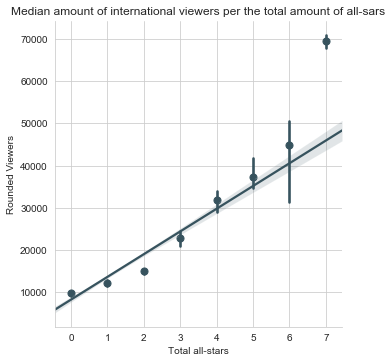

```python
p2 = sns.lmplot(x="Total_all_stars", y="Rounded Viewers", data=final_df, x_estimator=np.median, order = 1)
p2.set(title = "Median amount of international viewers per the total amount of all-sars", xlabel =
      "Total all-stars")
```

#### 4.1.3 Findings

The figures above support our hypothesis that as the total number of all-stars increases then the amount of international viewers will increase as well. Furthermore, it is seen that since there is a good linear realtionship between the two variables, it is a good indicator that if this feature is included in the predictive model then it will may have a high coefficient due to its high correlation. Finally, from this it can be concluded that a game will have a high amount of international viewers if that game includes alot of all-stars

### 4.2 Team record

In this section, we will observe the viewership numbers relative to how successful a team is doing (i.e.- high win percentages). Not necessarily to explore the idea of a "band-wagon" fan, but we aim to see if international viewers are actually interested in watching better teams or if viewership is independent of team success.

#### 4.2.1 Methodolgy

- greater than 75% : Top
- less than 75% and greater than 50% : Upper-Mid
- less than 50% and greater than > 25% : Lower-Mid
- less than 25%: Bottom

Next, to check the relationship among the amount of international viewers and winning percetange we looked at the team with highest winning percentage per game.

#### 4.2.2 Analysis

```python
# Getting total games per team before entering a game, and subsetting it to set a minimum amount of games played so
# data is not biased
winnings = game_dat
winnings["total_games"] = winnings["Wins_Entering_Gm"] + winnings["Losses_Entering_Gm"]
sub_dat = winnings[winnings["total_games"] > 70]

# Getting the team with the highest winning percentage per game_id
sub_dat["win_rate"] = (sub_dat["Wins_Entering_Gm"] / sub_dat["total_games"])
best_win = pd.DataFrame(sub_dat.groupby("Game_ID")["win_rate"].max())

# Combining the data we got above to the amount of international viewers per game
games = tot_view_dat.join(best_win)

# Assigning a label based off the winning percentage
def label(win_rate):
    '''Takes a win_rate and applies the appropriate label describing their win percentage.'''
    return np.where(win_rate >= 0.75, '75% <= win-rate',
                    (np.where(win_rate < 0.75 and win_rate > 0.50 , '50% < win-rate < 75%',
                              (np.where(win_rate > 0.25, '25% < win-rate < 50%', 'win-rate < 25%')))))

# create new column with the labels for each winning percentage
games["win_rate_label"] = games["win_rate"].apply(label)
win_rec = games[games.win_rate.notnull()].reset_index()
win_rec.head()
```

|  | Game_ID | Rounded Viewers | win_rate | win_rate_label |
| --- | --- | --- | --- | --- |
| 0 | 21600940 | 16527 | 0.500000 | 25% < win-rate < 50% |
| 1 | 21601058 | 9467 | 0.591549 | 50% < win-rate < 75% |
| 2 | 21601059 | 7160 | 0.366197 | 25% < win-rate < 50% |
| 3 | 21601060 | 13317 | 0.633803 | 50% < win-rate < 75% |
| 4 | 21601061 | 6898 | 0.478873 | 25% < win-rate < 50% |

```python
# Gets average viewership per label
win_rec = pd.DataFrame(games.groupby("win_rate_label")["Rounded Viewers"].mean()).reset_index()
win_rec = win_rec.reindex([3,0,1,2]).reset_index(drop = True)
win_rec
```

|  | win_rate_label | Rounded Viewers |
| --- | --- | --- |
| 0 | win-rate < 25% | 17491.428655 |
| 1 | 25% < win-rate < 50% | 7525.028571 |
| 2 | 50% < win-rate < 75% | 14975.152174 |
| 3 | 75% <= win-rate | 21395.034483 |

```python
df2 = win_rec[['win_rate_label','Rounded Viewers']].set_index('win_rate_label')
df2.iplot(kind='bar', xTitle='Win-Rate Group', yTitle='Average Viewership',
    title='Average International Viewership Per Game by Win-Rate')
df2
# create column based on condition <https://chrisalbon.com/python/data_wrangling/pandas_create_column_using_conditional/
# multiple conditions <https://stackoverflow.com/questions/39109045/numpy-where-with-multiple-conditions/39111919>
```

[interactive chart not shown]

| win_rate_label | Rounded Viewers |
| --- | --- |
| win-rate < 25% | 17491.428655 |
| 25% < win-rate < 50% | 7525.028571 |
| 50% < win-rate < 75% | 14975.152174 |
| 75% <= win-rate | 21395.034483 |

### 4.3 Closeness of the game

We were interested in seeing if the international audience of the NBA tends to watch an NBA game if its a close game. As fans of the NBA, we predict that the closer the game is the more viewers that game will have.

#### 4.3.1 Methodology

So to explore this feature from the game data we looked at point deficit in the last two minutes. In the game data we were given the last two minute score for each of the two teams per game. Given that we were able to compute the point deficit in the last two minutes for each game.

#### 4.3.2 Analysis

```python
def get_dif(num):
    ''' The function takes in a game id and computes last 2 min point deficit for that game'''
    x = game_dat[game_dat["Game_ID"] == num].reset_index()
    dif = abs(x["L2M_Score"][0] - x["L2M_Score"][1])
    return dif
```

```python
# Gets the l2m point deficit
new_dat = game_dat
deficit = game_dat["Game_ID"].apply(get_dif)
new_dat["ptd"] = deficit

# Will get data on the l2m point deficit per game id and merge it with data on total viewers per game_id
ptd_dat = pd.DataFrame(new_dat.groupby("Game_ID")["ptd"].max())
ptd_vs_views = tot_view_dat.join(ptd_dat)
```

The figure below shows a regression line fitted through the average amount of viewers per point defcit in the last 2 minutes of the game. From this it can be seen that there is a trend because for the most part as the point deficit increases the viewership on average falls.

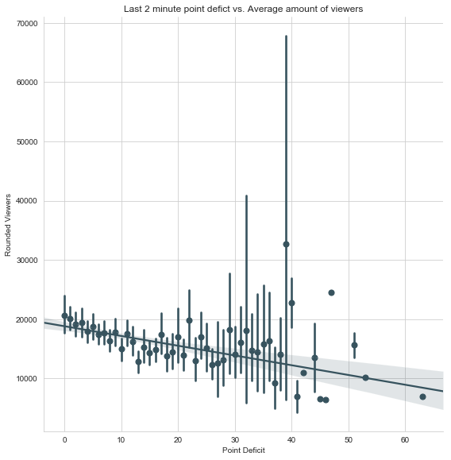

```python
plt.rcParams["figure.figsize"] = [50, 10]
p3 = sns.lmplot(x = "ptd", y = "Rounded Viewers",x_estimator = np.mean, data = ptd_vs_views, height = 8)
p3.set(title = "Last 2 minute point defict vs. Average amount of viewers", xlabel = "Point Deficit")
```

#### 4.3.3 Findings

There is an inverse relationship. among international viewers and the last two minute point deficit because as the point deficit increases the average amount of viewrship decreases. Our results did live up to our hypothesis, but the strength of the relationship is not as strong as we expected. We believe, that this is possibly due to some games being between two low level teams.

### 4.5 Final Score

We want to see if final scores of a game could be a predictive indicator of game viewership. We hypothesize that games with higher final scores could correlate with higher game viewership.

#### 4.5.1 Methodology

We want to see if final scores of a game could be a predictive indicator of game viewership. We hypothesize that games with higher final scores could correlate with higher game viewership.

### 4.5.2 Analysis

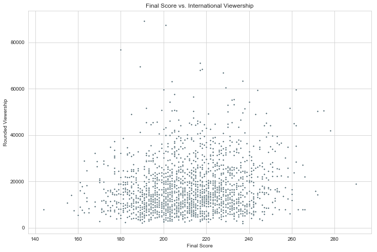

```python
rounded_viewers = training_set[['Game_ID','Rounded Viewers']]
final_score = game_dat[['Game_ID','Final_Score']]

sum_final_scores = pd.DataFrame(final_score.groupby('Game_ID')['Final_Score'].sum())
sum_views = pd.DataFrame(rounded_viewers.groupby('Game_ID')['Rounded Viewers'].sum())
merged = pd.merge(sum_views, sum_final_scores, on="Game_ID")
merged_viewers = merged.sort_values(by=['Rounded Viewers'])
plt.figure(figsize=(12,8))
ax = sns.scatterplot(x='Final_Score', y='Rounded Viewers', data=merged, s=10)
ax.set_title('Final Score vs. International Viewership')
ax.set_xlabel('Final Score')
ax.set_ylabel('Rounded Viewership')
ax
```

#### 4.5.3 Findings

There appears to be no strong correlation between game finals scores and game viewership. The games with the highest viewership had final scores that were on the lower end of the final scores range. Thus, our hypothesis is incorrect-- high final scores is not indicative of high game viewership.

## 4.6 Total Time outs

We were interested in investigating the relationship among total timeouts in a game taken and the international viewership for that game. We hypothesisze that there will be a negative relationship, because we felt as if a game uses more timeouts it will reduce the amount of followers or cause them to change the channel.

#### 4.6.1 Methodology

In order to investigate this feature we took the sum of full and short timeouts per team for each game id. We then merged it with the data on total rounded viewers per game id to perform further analysis

#### 4.6.2 Analysis

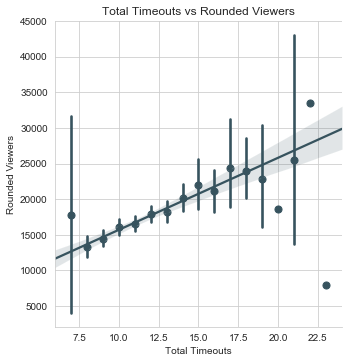

```python
games = game_dat.copy()
Full_Timeouts1 = games.groupby(["Game_ID"])["Full_Timeouts"].max() # full timeouts for team one
Full_Timeouts2 = games.groupby(["Game_ID"])["Full_Timeouts"].min() # full timeouts for team two (may be same as other team)
Short_Timeouts1 = games.groupby(["Game_ID"])["Short_Timeouts"].max() # short timeouts for team one
Short_Timeouts2 = games.groupby(["Game_ID"])["Short_Timeouts"].min() # short timeouts for team two (may be same as other team)]
Full_Timeouts = pd.DataFrame(Full_Timeouts1 + Full_Timeouts2) # total full timeouts for that game
Short_Timeouts = pd.DataFrame(Short_Timeouts1 + Short_Timeouts2) # total full timeouts for that game
Total_Timeouts = pd.DataFrame(Full_Timeouts["Full_Timeouts"] + Short_Timeouts["Short_Timeouts"]) # sum timeouts for ea. game
tot_timeouts = Total_Timeouts.reset_index().rename(index=str, columns={0:"total_timeouts"})
final_data = pd.merge(tot_view_dat, tot_timeouts, on=['Game_ID'], how = 'left')

plt.figure(figsize=(12,8))
ax = sns.lmplot(x='total_timeouts', y='Rounded Viewers', data= final_data, x_estimator = np.mean)
ax.set(title = "Total Timeouts vs Rounded Viewers", xlabel = "Total Timeouts", ylabel = "Rounded Viewers")
ax
```

#### 4.6.3 Findings

The figure above shows the average amount of international viewers per total time outs taken in the game. Though there is a relationship among the variables, it is not the relationship we hypothesized. This is because the figure above shows that as the amount of timeouts in a game increases then this will result in a higher amount of international viewrship. In conclusion, we believe this may be due to the fact that timeouts will usually be called more often if the game is close.

## 5 Predictive Model

Now that we explored various features in depth that we believed would influence international viewership. Next we will use some of these features to construct a linear regression model to predict future international viewership.

**Features implemented into model**

- Total Final Score
- Total All Stars in Game
- Avg Views Per Game by Date
- Combined Wins Entering Game
- Highest Scorer in Game
- Total Timeouts Called

### 5.1 Features

```python
# Feature 1 : Average Viewers Per Game by Game Date
# average viewers per game for each unique date
data = training_dat.copy().drop(["Country"], axis=1) # drop unneeded columns
data = pd.DataFrame(data.groupby(["Season","Game_ID","Game_Date","Away_Team","Home_Team"])["Rounded Viewers"].sum().reset_index()) # distinct games
main = training_dat.copy()
train_bydate = training_dat.copy()
games = game_dat.copy()
players = player_dat.copy()

train_bydate["Game_Date"] = pd.to_datetime(train_bydate["Game_Date"])
train_bydate["Game_ID"] = train_bydate["Game_ID"].apply(str)
tot_views_unique_game = train_bydate.groupby(["Game_ID","Game_Date"])["Rounded Viewers"].sum() # total viewers for each unique game
tot_views_unique_game_df = pd.DataFrame(tot_views_unique_game.reset_index())
avg_views_by_date = tot_views_unique_game_df.groupby("Game_Date")["Rounded Viewers"].mean() # average viewers per game for each date

def get_avg_viewership_per_game_for_unique_date(game_date):
    '''Takes a game_date string and finds the corresponding average viewership per game for that date, by indexing
    the "avg_views_by_date" Series'''
    return avg_views_by_date[game_date]

avg_views_per_game_for_game_date = data["Game_Date"].apply(get_avg_viewership_per_game_for_unique_date)
id_and_feature = pd.DataFrame({"Game_ID":data["Game_ID"], "avg_views_per_game_for_game_date":avg_views_per_game_for_game_date})
data = pd.merge(data, id_and_feature, on=['Game_ID'], how = 'left')

# Feature 2: Final Scores
rounded_viewers = main[['Game_ID','Rounded Viewers']]
final_score = games[['Game_ID','Final_Score']]
sum_final_scores = pd.DataFrame(final_score.groupby('Game_ID')['Final_Score'].sum())
sum_views = pd.DataFrame(rounded_viewers.groupby('Game_ID')['Rounded Viewers'].sum())
merged = pd.merge(sum_views, sum_final_scores, on="Game_ID")
merged = merged.reset_index()
merged = merged.drop(columns=["Rounded Viewers"])
data = pd.merge(data, merged, on=['Game_ID'], how = 'left')

# Feature 3: Total Timeouts
Full_Timeouts1 = games.groupby(["Game_ID"])["Full_Timeouts"].max() # full timeouts for team one
Full_Timeouts2 = games.groupby(["Game_ID"])["Full_Timeouts"].min() # full timeouts for team two (may be same as other team)
Short_Timeouts1 = games.groupby(["Game_ID"])["Short_Timeouts"].max() # short timeouts for team one
Short_Timeouts2 = games.groupby(["Game_ID"])["Short_Timeouts"].min() # short timeouts for team two (may be same as other team)]
Full_Timeouts = pd.DataFrame(Full_Timeouts1 + Full_Timeouts2) # total full timeouts for that game
Short_Timeouts = pd.DataFrame(Short_Timeouts1 + Short_Timeouts2) # total full timeouts for that game
Total_Timeouts = pd.DataFrame(Full_Timeouts["Full_Timeouts"] + Short_Timeouts["Short_Timeouts"]) # sum timeouts for ea. game
tot_timeouts = Total_Timeouts.reset_index().rename(index=str, columns={0:"total_timeouts"})
data = pd.merge(data, tot_timeouts, on=['Game_ID'], how = 'left')

# Feature 4: Max Scorer in Game
highest_scorer = pd.DataFrame(players.groupby(["Game_ID"])["Points"].max().reset_index()) # highest scorer for each game
data = pd.merge(data, highest_scorer, on=['Game_ID'], how = 'left')

# Feature 5: Wins Entering Game
# can just take highest team because most will probably look to be watching the better team
wins_entering_game1 = games.groupby(["Game_ID"])["Wins_Entering_Gm"].max().reset_index()["Wins_Entering_Gm"]
wins_entering_game2 = games.groupby(["Game_ID"])["Wins_Entering_Gm"].min().reset_index()["Wins_Entering_Gm"]
wins_entering_game = wins_entering_game1 + wins_entering_game2
id_and_wins_entering_game = pd.DataFrame({"Game_ID":games.groupby("Game_ID").max().reset_index()["Game_ID"],"wins_entering_game":wins_entering_game})
id_and_wins_entering_game.head(1)
data = pd.merge(data, id_and_wins_entering_game, on=['Game_ID'], how = 'left')
# can just take highest team because most will probably look to be watching the better team
games["Game_Date"] = pd.to_datetime(games["Game_Date"]) # convert to date
# ignore first 40 games of season
start_date = '2016-12-01'
end_date = '2017-4-13'
season1 = games[(games["Game_Date"] > start_date) & (games["Game_Date"] < end_date)]
wins_entering_game = season1.groupby(["Game_ID"])["Wins_Entering_Gm"].max().reset_index()["Wins_Entering_Gm"]
id_and_wins_entering_game = pd.DataFrame({"Game_ID":season1.groupby("Game_ID").max().reset_index()["Game_ID"],"wins_entering_game_2":wins_entering_game})
data = pd.merge(data, id_and_wins_entering_game, on=['Game_ID'], how = 'left')

# Feature 6: Number of all-stars
all_stars = players[players["ASG_Team"] != "None"]
all_stars = all_stars[all_stars["Active_Status"] == "Active"]
total_per_game = all_stars["Game_ID"].value_counts()
total = pd.DataFrame(total_per_game)
total_allstars = total.reset_index().sort_values("index").reset_index(drop = True)
total_allstars = total_allstars.rename(index=str, columns={"index": "Game_ID", "Game_ID": "Number_allstars"})
#all_stars = pd.DataFrame(all_stars.groupby("Game_ID")["ASG_Team"].count())
data = pd.merge(data, total_allstars, on=['Game_ID'], how = 'left')
data.head()
```

|  | Season | Game_ID | Game_Date | Away_Team | Home_Team | Rounded Viewers | avg_views_per_game_for_game_date | Final_Score | total_timeouts | Points | wins_entering_game | wins_entering_game_2 | Number_allstars |
| --- | --- | --- | --- | --- | --- | --- | --- | --- | --- | --- | --- | --- | --- |
| 0 | 2016-17 | 21600001 | 10/25/2016 | NYK | CLE | 57691 | 52953.000000 | 205.0 | 11.0 | 29.0 | 0 | NaN | 4.0 |
| 1 | 2016-17 | 21600002 | 10/25/2016 | UTA | POR | 40740 | 52953.000000 | 217.0 | 12.0 | 39.0 | 0 | NaN | NaN |
| 2 | 2016-17 | 21600003 | 10/25/2016 | SAS | GSW | 60428 | 52953.000000 | 229.0 | 10.0 | 35.0 | 0 | NaN | 5.0 |
| 3 | 2016-17 | 21600004 | 10/26/2016 | MIA | ORL | 22756 | 24487.555556 | 204.0 | 11.0 | 20.0 | 0 | NaN | NaN |
| 4 | 2016-17 | 21600005 | 10/26/2016 | DAL | IND | 33922 | 24487.555556 | 251.0 | 18.0 | 30.0 | 0 | NaN | 1.0 |

### 5.2 Exploratory Data Analysis

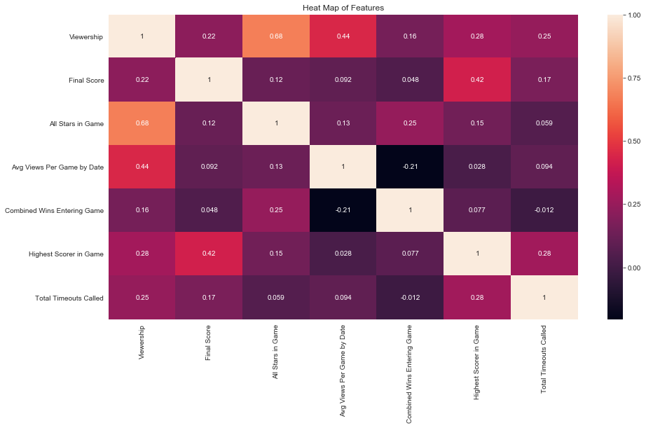

```python
# Remove non numerical columns
prediction_data = data
prediction_data = prediction_data.drop(columns=['Season', 'Game_ID',"Game_Date","Away_Team","Home_Team"])

# prediction data
p_data = prediction_data[["Rounded Viewers","Final_Score","Number_allstars","avg_views_per_game_for_game_date","wins_entering_game_2","Points","total_timeouts"]].copy().dropna()
p_data = p_data.rename(index=str, columns={"Rounded Viewers":"Viewership",
                                           "Final_Score":"Final Score",
                                           "Number_allstars":"All Stars in Game",
                                           "avg_views_per_game_for_game_date":"Avg Views Per Game by Date",
                                           "wins_entering_game_2":"Combined Wins Entering Game",
                                           "Points":"Highest Scorer in Game",
                                           "total_timeouts":"Total Timeouts Called"})

fig = plt.figure()
plt.figure(figsize=(15,8))
ax = sns.heatmap(p_data.corr(),annot = True)
ax.set_title("Heat Map of Features")
plt.show()
# fig.savefig('heatmap.png')
```

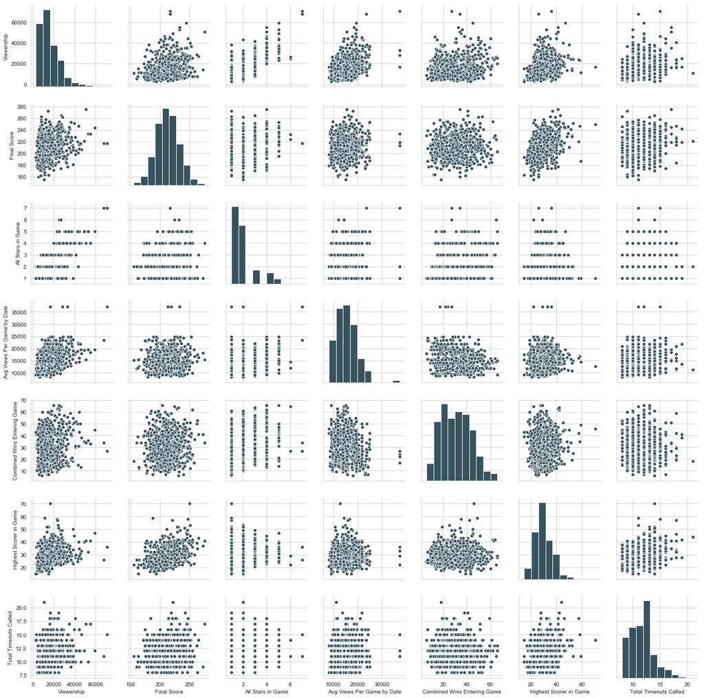

```python
sns.pairplot(p_data)
```

```
Coefficients:
 [2.59022430e+01 5.14957627e+03 7.71859488e-01 3.75830431e+01
 1.29997171e+02 7.31387208e+02]
```

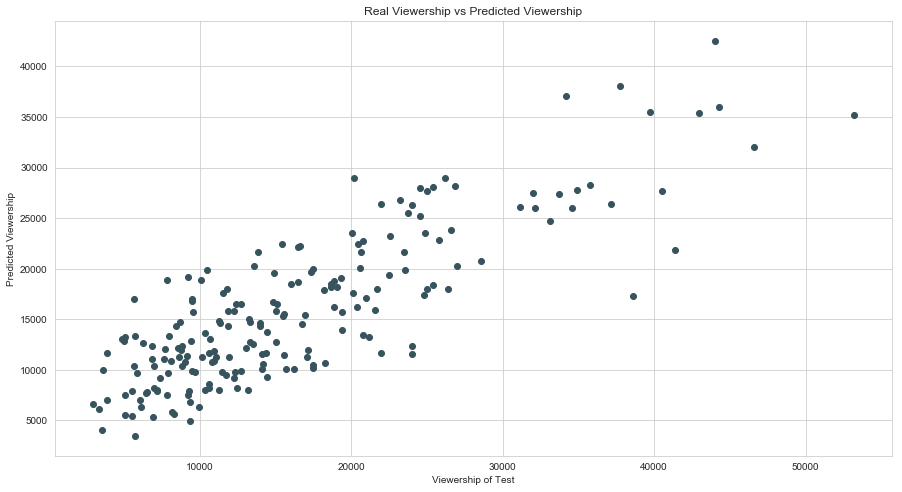

```python
# Split into features to train on and target variable
y = p_data["Viewership"]
X = p_data[['Final Score', 'All Stars in Game',
       'Avg Views Per Game by Date', 'Combined Wins Entering Game',
       'Highest Scorer in Game', 'Total Timeouts Called']]

# Split data into Train and Test
X_train, X_test, y_train, y_test = train_test_split(X, y, test_size=0.3, random_state=0)

# Instantiate Model
lm = LinearRegression() # create instance
lm.fit(X_train,y_train) # train/fit on training data. This trains the model

# Coefficients of Model
print('Coefficients: \n', lm.coef_)

# Predicting Test Data
predictions = lm.predict(X_test)

# plot actual vs predicted
plt.figure(figsize=(15,8))
plt.scatter(y_test,predictions)
plt.xlabel('Viewership of Test')
plt.ylabel('Predicted Viewership')
plt.title("Real Viewership vs Predicted Viewership")
```

### 5.3 Evaluate Model

```
MAE: 4105.774800604605
R-squared:  0.6923267790768239
```

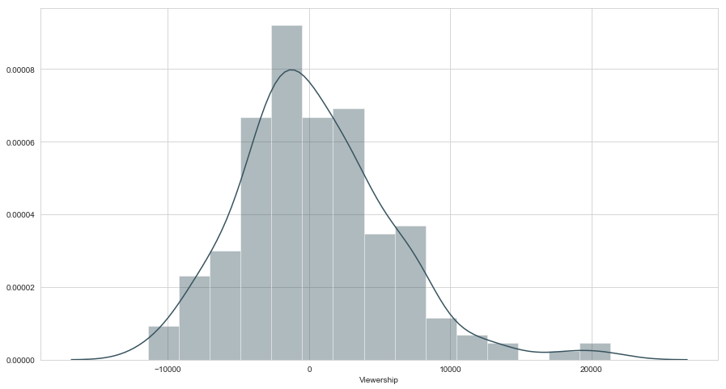

```python
## Evaluating the Model
from sklearn import metrics

print('MAE:', metrics.mean_absolute_error(y_test, predictions))
print('R-squared: ', metrics.explained_variance_score(y_test,predictions)) # R^2

# check residuals distribution
plt.figure(figsize=(15,8))
sns.distplot((y_test-predictions));
```

The residuals of the predictions is normally distributed, therefore this is an indication the linear regression model is appropriate.

## Conclusion

```python
coeffecients = pd.DataFrame(lm.coef_,X.columns)
coeffecients.columns = ['Coeffecient']
coeffecients
```

|  | Coeffecient |
| --- | --- |
| Final Score | 25.902243 |
| All Stars in Game | 5149.576274 |
| Avg Views Per Game by Date | 0.771859 |
| Combined Wins Entering Game | 37.583043 |
| Highest Scorer in Game | 129.997171 |
| Total Timeouts Called | 731.387208 |

The coefficients tells us if we hold all others features fixed a 1 unit increase in that feature is associated with an increase of the coefficient value. From this we know that the number of all stars in a game is associated with the greatest increase of viewers when all other features are fixed.

To validate the assumptions of our predictive model we checked the distribution of the residuals. Since we got that the distribution is approximately normal, we can confidently say that the linear regression model was an appropriate model for the data.

After creating a linear regression model to predict international viewership, we were able to able an average predicted error of about 4100. Considering the fact that was apparent in prior visualizations, the average error we obtained is not so bad, since the average viewership per game can range anywhere from 1,000 viewers to over 80,000 viewers.